# Reproducible Research Project 1

Rodrigo

4/14/2021

Download the data

```r
data <- read.csv("activity.csv")
library(tidyverse)
```

```r
library(ggplot2)
```

Grouping by date, summarizing by total steps, and removing the NA

```r
steps_per_day <- data %>% group_by(date) %>% summarise(steps=sum(steps, na.rm = TRUE))
```

What is mean total number of steps taken per day? Plotting the Total number of steps taken per day

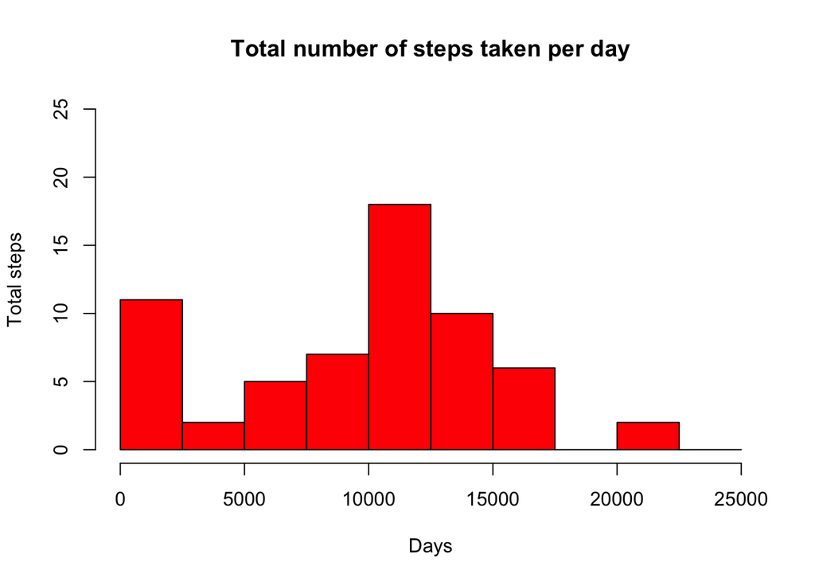

```r
hist(steps_per_day$steps, main = "Total number of steps taken per day",
     xlab = "Days", ylab = "Total steps", col = "red", ylim = c(0,25),
     breaks = seq(0,25000, by=2500))
```

Creating the mean and median of steps per each day

```r
steps_per_day_mean <- data %>% group_by(date) %>% summarise(steps=mean(steps, na.rm = TRUE))
steps_per_day_median <- data %>% group_by(date) %>% summarise(steps=median(steps, na.rm = TRUE))
mean_media_combined <- cbind(steps_per_day_mean[,1:2], steps_per_day_median[,2])
colnames(mean_media_combined) <- c("date", "mean steps", "median steps")
```

Creating the mean and median of steps for total days

```r
mean(steps_per_day$steps, na.rm = TRUE)
```

```
## [1] 9354.23
```

```r
median(steps_per_day$steps, na.rm = TRUE)
```

```
## [1] 10395
```

What is the average daily activity pattern? Creating a dataframe to plot Steps per interval

```r
steps_per_interval_mean <- data %>% group_by(interval) %>% summarise(steps=mean(steps, na.rm = TRUE))
```

Plotting Steps per interval

```r
graph <- ggplot(data = steps_per_interval_mean, aes(x=interval, y= steps))
```

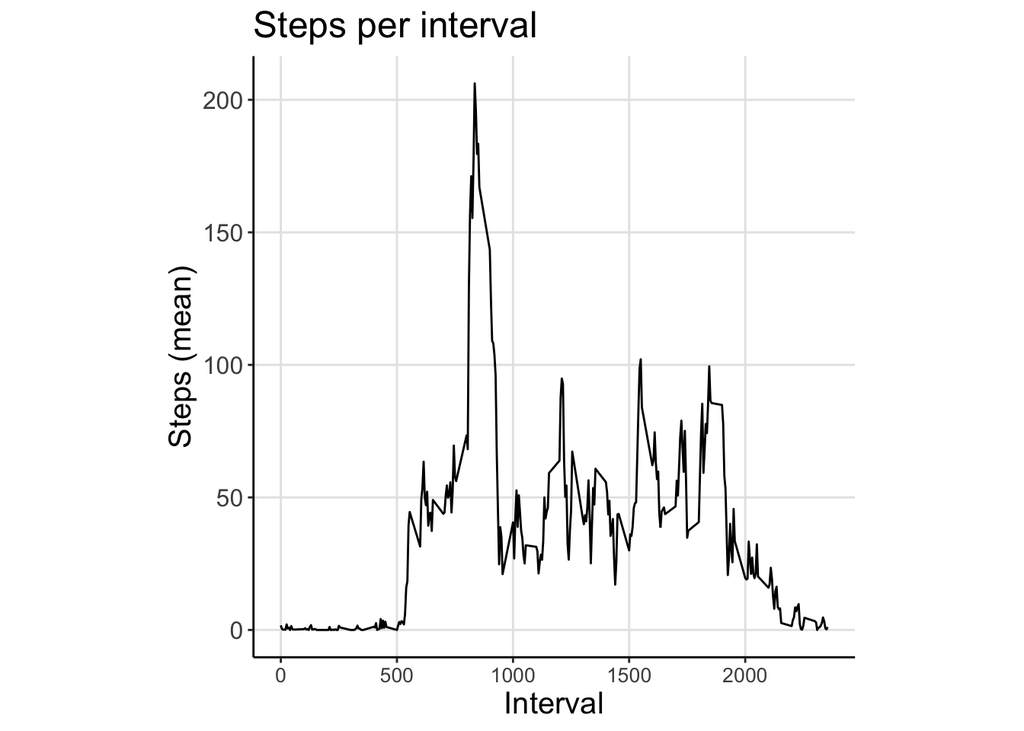

```r
graph +  geom_line() +
    ggtitle("Steps per interval") +
    xlab("Interval") +
    ylab("Steps (mean)") +
    expand_limits(x=c(1)) +

    theme(panel.border = element_blank(),
          panel.background = element_rect(fill = NA),
          panel.grid.major = element_line(colour= "gray90"),
          panel.grid.minor = element_blank(),
          axis.line = element_line(colour = "black", size = 0.5),
          text = element_text(size = 15),
          axis.title.y= element_text(colour= "black", size= 15),
          axis.text.x= element_text(size=10),
          legend.title = element_text(size=7),
          legend.text= element_text(size=7),
          legend.position= c(1.3, 0.5),
          legend.justification = c(1.3, .5),
          aspect.ratio = 1)
```

Finding the max maximun number of steps in wihich interval

```r
steps_per_interval_mean[which.max(steps_per_interval_mean$steps), ]$interval
```

```
## [1] 835
```

Finding the number of missing data (NA) in the steps

```r
sum(is.na(data$steps))
```

```
## [1] 2304
```

```r
data_1 <- data
missing_data <- is.na(data$steps)
mean_imput <- mean(steps_per_day_mean$steps, na.rm = TRUE)
```

```r
data_1$missing <- missing_data
data_1$missing <- mean_imput
final_table <- aggregate(steps~date, data_1, sum)
```

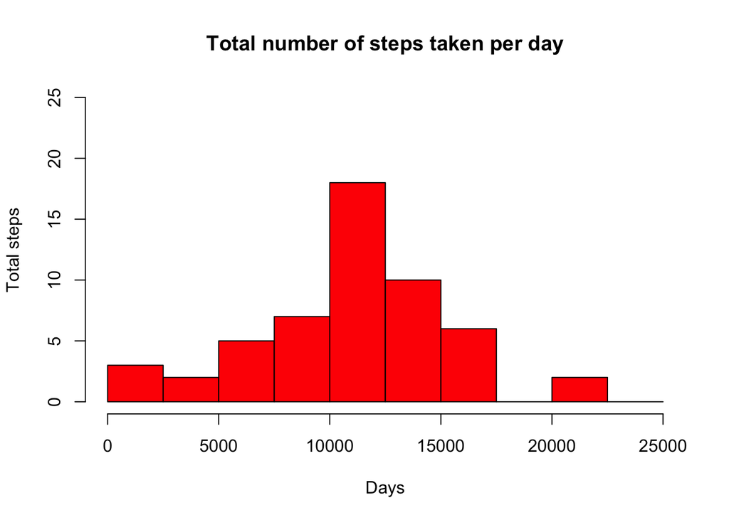

```r
hist(final_table$steps, main = "Total number of steps taken per day",
     xlab = "Days", ylab = "Total steps", col = "red", ylim = c(0,25),
     breaks = seq(0,25000, by=2500))
```

```r
mean(final_table$steps)
```

```
## [1] 10766.19
```

```r
median(final_table$steps)
```

```
## [1] 10765
```

Are there differences in activity patterns between weekdays and weekends? Converting the column date to date format

```r
data$date <- as.Date(strptime(data$date, format="%Y-%m-%d"))
```

Including a new column “day” with the characters Weekend and Weekday

```r
data_2 <- data %>%
    mutate(day = ifelse(weekdays(data$date)== "Saturday" | weekdays(data$date)== "Sunday", "Weekend", "Weekday"))
```

Getting the steps mean grouping by interval and day

```r
mean_day <- data_2 %>% group_by(interval, day) %>% summarise(steps=mean(steps, na.rm = TRUE))
```

Plotting the mean steps dividing the graphs by Weekend and Weekday

```r
graph <- ggplot(data = mean_day, aes(x=interval, y= steps))
```

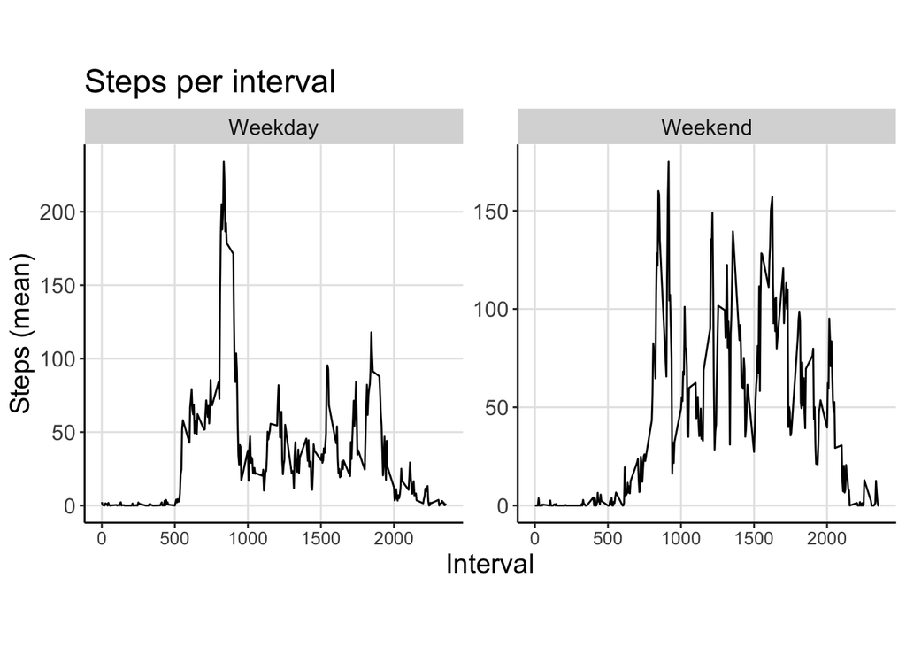

```r
graph +  geom_line() +
    ggtitle("Steps per interval") +
    xlab("Interval") +
    ylab("Steps (mean)") +
    expand_limits(x=c(1)) +

    facet_wrap(~ day, ncol = 2, scales = "free") +

    theme(panel.border = element_blank(),
          panel.background = element_rect(fill = NA),
          panel.grid.major = element_line(colour= "gray90"),
          panel.grid.minor = element_blank(),
          axis.line = element_line(colour = "black", size = 0.5),
          text = element_text(size = 15),
          axis.title.y= element_text(colour= "black", size= 15),
          axis.text.x= element_text(size=10),
          legend.title = element_text(size=7),
          legend.text= element_text(size=7),
          legend.position= c(1.3, 0.5),
          legend.justification = c(1.3, .5),
          aspect.ratio = 1)
```